# Woodbine School District — NJ School Data Almanac – NJ District Profiles

NJ School Data Almanac

Woodbine School District

CAPE MAY COUNTY · TRADITIONAL PUBLIC DISTRICT · DFG A · 247 STUDENTS (2026)

247

Students

20.3%

Gr 3-8 ELA

36.4%

Chronically absent

$17,708

Per pupil

*7 things the data says about Woodbine School District. Every figure is computed from New Jersey Department of Education data via the njschooldata package — nothing is estimated. Comparisons use District Factor Group (DFG) peers (39 districts in DFG A).*

No. 1 EQUITY

## Woodbine Girls Hit 50% Proficiency in Reading in 2024 — Boys Reached 6.7%

A 43-point gender gap on the 2024 state reading test is among the starkest splits visible in this tiny Cape May County district’s data.

On the 2024 New Jersey Student Learning Assessment in English language arts, half of Woodbine’s girls in grades 3-8 scored proficient or above. Among boys, the figure was 6.7 percent. That 43.3-point gap dwarfs the district’s overall ELA mark of 20.3 percent and is the single widest subgroup split surfaced anywhere in Woodbine’s testing data.

Because Woodbine is a K-8 district of just 247 students, each grade-level cohort is small, and a handful of children can swing a percentage sharply. Even so, the contrast is hard to ignore: girls outperformed the district average by nearly 30 points while boys trailed it by almost 14. The district’s largest racial group on the test, Hispanic students, posted 20.8 percent proficiency, essentially matching the overall rate, while students with special-education accommodations registered 0.0 percent.

Gender gaps in reading favoring girls are common nationally, but a split this size raises questions a single year of data cannot answer. Is 2024 an anomaly driven by small cohorts, or the leading edge of a pattern? With boys making up a sizable share of a 247-student school, what would it take to close a gap this wide?

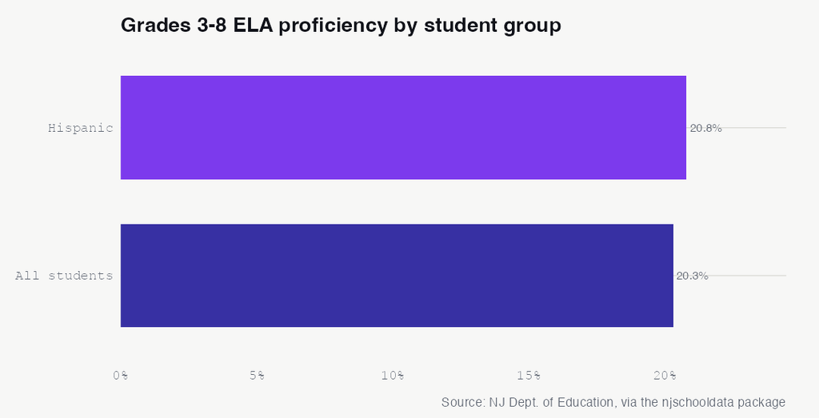

See the underlying data ›

No. 2 ACHIEVEMENT

## Woodbine’s Reading Proficiency Fell by Half in One Year, From 40.7% to 20.3%

After holding steady through the pandemic, the district’s grades 3-8 reading scores dropped 20 points between 2023 and 2024.

Woodbine’s reading results had been a quiet success story. ELA proficiency on the state’s grades 3-8 assessment climbed from 32.1 percent in 2017 to 39.3 percent by 2019, then held remarkably firm through the pandemic — 38.5 percent in 2022 and 40.7 percent in 2023 — even as many districts saw COVID-era declines. Then, in 2024, it fell to 20.3 percent, cutting the proficiency rate nearly in half in a single year.

Math tells a different but equally pointed story. Proficiency peaked at 26.4 percent in 2019, collapsed to 10.4 percent in 2022, briefly recovered to 17.0 percent in 2023, and slid back to 10.7 percent in 2024. Where reading once buffered the district against pandemic learning loss, by 2024 both subjects sat near their lowest points in the available record.

A one-year drop of this magnitude in a 247-student district can reflect a single small cohort, a staffing change, or a genuine shift in instruction. The data marks the turn clearly but cannot explain it. Was 2024 a one-year shock, and will the classes that follow rebound toward the 40 percent reading mark the district held just a year earlier?

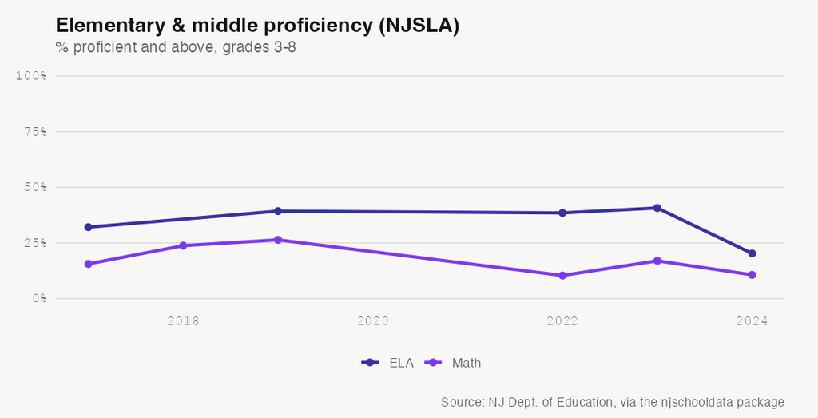

See the underlying data ›

No. 3 ATTENDANCE

## More Than 1 in 3 Woodbine Students Were Chronically Absent in 2024 — Versus 1 in 4 Across Peer Districts

Chronic absenteeism nearly doubled from its pre-pandemic level and sits well above the median for similar high-need districts.

In 2024, 36.4 percent of Woodbine’s students were chronically absent — missing at least 10 percent of the school year. That is far above the 24.1 percent median among the district’s District Factor Group A peers, the lowest-income band of New Jersey districts, and nearly double Woodbine’s own pre-pandemic rate of 19.0 percent in 2019.

The spike was sudden and persistent. Chronic absenteeism jumped to 37.6 percent in 2021, eased only slightly to 36.7 percent in 2022 and 34.5 percent in 2023, then ticked back up to 36.4 percent in 2024. Four years after the initial disruption, more than a third of students are still missing enough school to fall behind, with little sign of a return to 2019 levels.

Attendance and achievement tend to move together, and Woodbine’s 2024 reading and math scores fell in the same year its absenteeism stayed elevated. The data cannot say which drove which. With the district sitting more than 12 points above its peer median, what would pull attendance back toward where it stood before 2020?

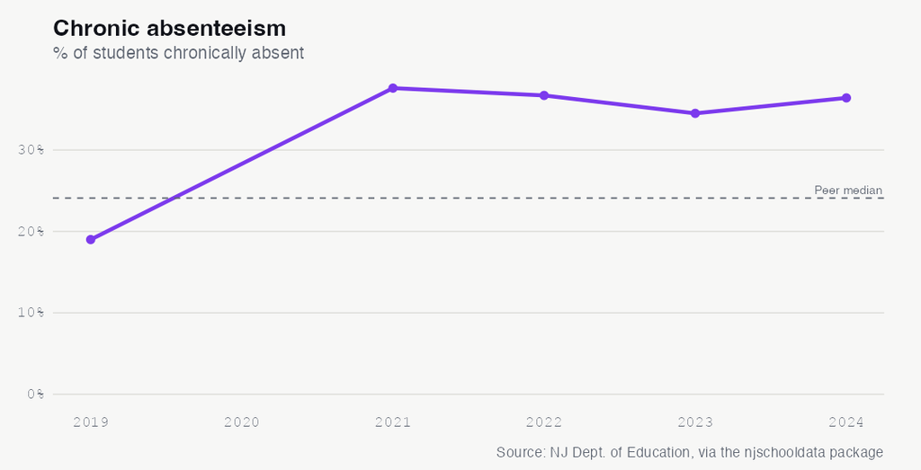

See the underlying data ›

No. 4 DEMOGRAPHICS

## Woodbine’s Black Enrollment Share Fell From 35.9% to 18.6% Since 2015 as Hispanic Share Climbed Past 46%

In 2015, Woodbine’s students were split fairly evenly among three groups: 35.9 percent Black, 32.6 percent Hispanic, and 31.5 percent white. By 2026 the balance had shifted sharply. Black students fell to 18.6 percent of enrollment — a drop of 17.3 percentage points and the district’s single largest demographic change — while Hispanic students rose to 46.2 percent, up nearly 14 points and now close to half the school.

The white share held roughly steady, ending at 26.3 percent, but a new group emerged: students identified as multiracial, who were not recorded at all in 2015 and 2016 but reached 10.5 percent in 2025 before settling at 8.9 percent in 2026. The transformation unfolded mostly between 2015 and 2022, when the Hispanic share crossed from a third to nearly half of the district.

In a school this small, demographic shifts can reflect just a few families moving in or out each year. The data documents a clear, sustained change rather than a one-year blip. As the district’s makeup continues to evolve, will its programs and staffing keep pace with a student body that looks markedly different than it did a decade ago?

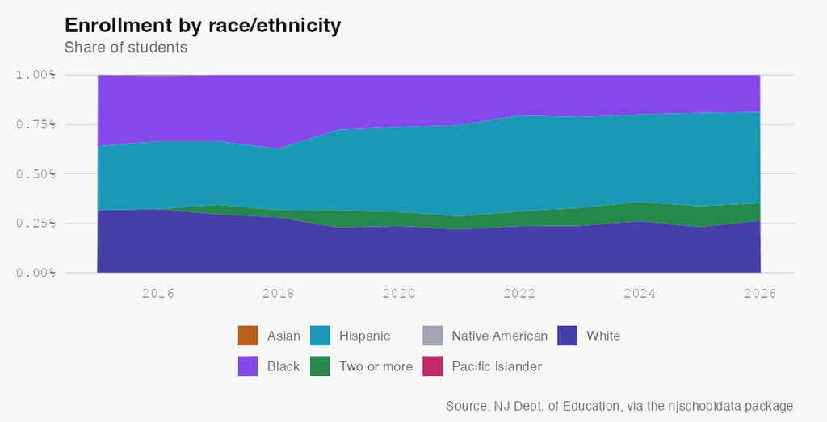

See the underlying data ›

No. 5 FINANCE

## Woodbine Spends $17,708 Per Student — Below the Median for Similar Districts, at the 33rd Percentile

Despite serving a high-need population, the district’s per-pupil spending trails the typical District Factor Group A district by more than $1,600.

Woodbine spent $17,708 per pupil in 2024, placing it at the 33rd percentile among its 39 District Factor Group A peers — the band of New Jersey’s lowest-income districts. The peer median was $19,338, more than $1,600 higher. Spending has risen 21.0 percent since 2014, when the district reported $14,634 per pupil, but the increase has not lifted Woodbine above the middle of its peer group.

The data raises a familiar tension for small, high-need districts: a relatively low per-pupil figure paired with the costs of operating a full K-8 school for only about 250 students. With spending in the bottom third of its peers and proficiency rates that fell in 2024, would additional resources move outcomes — or are the constraints here about something other than dollars?

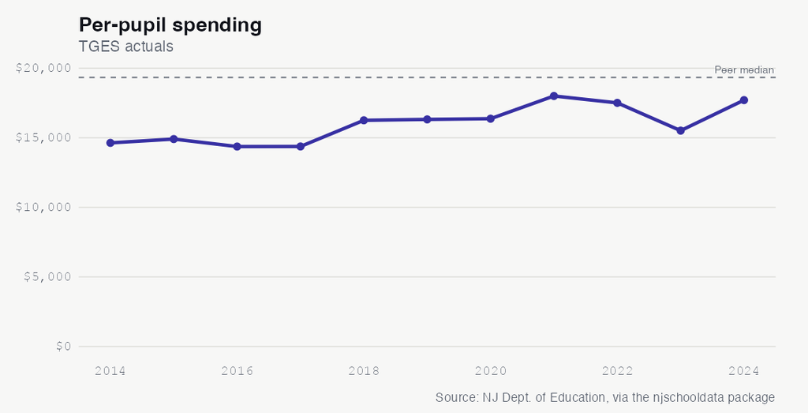

See the underlying data ›

No. 6 ENROLLMENT

## Woodbine Added 66 Students Since 2015, Growing 36% While Many Small NJ Districts Shrank

Enrollment climbed from a low of 181 to a peak of 257 before settling at 247, a rare expansion for a tiny rural district.

Woodbine enrolled just 181 students in 2015, its lowest count in the available record. Over the next decade it added 66 students, a 36.5 percent increase, reaching a peak of 257 in 2024 before easing to 247 in 2025 and holding flat in 2026. That growth runs against the trend for many small New Jersey districts, which have lost students to declining birth rates and out-migration.

For a K-8 school of this size, each year’s enrollment hinges on a relatively small number of families. The recent flattening at 247 raises a planning question the data leaves open: has Woodbine reached a new, higher steady state, or is the 2024 peak the high-water mark of a longer cycle?

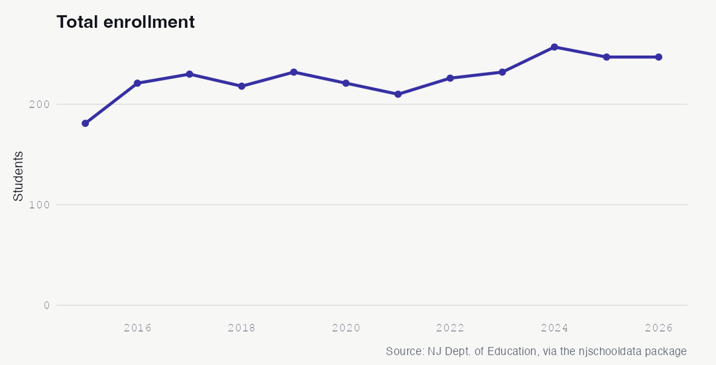

See the underlying data ›

No. 7 DEMOGRAPHICS

## Roughly 7 in 10 Woodbine Students Qualified for Subsidized Meals in 2026, Down From a Recent High of 81%

Economic-need figures have swung widely year to year, ending at 71.7 percent after touching 81 percent in 2025.

The figures have been volatile, swinging from 25.3 percent in 2020 to 73.9 percent in 2021 — movement that often reflects changes in how meal eligibility was counted and reported during the pandemic rather than real shifts in family circumstances. English-learner counts, by contrast, have grown more steadily, rising from a single student in 2016 to 24 students, or 9.7 percent, by 2026.

The high and persistent share of students who are economically disadvantaged underscores Woodbine’s status as a District Factor Group A district. As the economic and language profile of the student body holds at these levels, the data invites a question about whether supports for low-income and English-learner students are scaled to match the need.

See the underlying data ›

## The Almanac

The full longitudinal record behind the stories above. Every number a reader can check.

### Enrollment (total)

| year | students | yoy | yoy_pct |
| --- | --- | --- | --- |
| 2015 | 181 | NA | NA |
| 2016 | 221 | 40 | 22.1 |
| 2017 | 230 | 9 | 4.1 |
| 2018 | 218 | -12 | -5.2 |
| 2019 | 232 | 14 | 6.4 |
| 2020 | 221 | -11 | -4.7 |
| 2021 | 210 | -11 | -5 |
| 2022 | 226 | 16 | 7.6 |
| 2023 | 232 | 6 | 2.7 |
| 2024 | 257 | 25 | 10.8 |
| 2025 | 247 | -10 | -3.9 |
| 2026 | 247 | 0 | 0 |

### Demographic share (%) by year

| end_year | white | black | hispanic | asian | native_american | pacific_islander | multiracial |
| --- | --- | --- | --- | --- | --- | --- | --- |
| 2015 | 31.5 | 35.9 | 32.6 | 0 | 0 | 0 | 0 |
| 2016 | 32.1 | 33 | 34.4 | 0.5 | 0 | 0 | 0 |
| 2017 | 29.6 | 33.5 | 32.2 | 0 | 0 | 0 | 4.8 |
| 2018 | 28 | 37.2 | 31.2 | 0 | 0 | 0 | 3.7 |
| 2019 | 22.8 | 27.6 | 40.9 | 0 | 0 | 0 | 8.6 |
| 2020 | 23.5 | 26.2 | 43 | 0 | 0 | 0 | 7.2 |
| 2021 | 21.9 | 25.2 | 46.2 | 0 | 0 | 0 | 6.7 |
| 2022 | 23.5 | 20.4 | 48.7 | 0 | 0 | 0 | 7.5 |
| 2023 | 23.7 | 21.1 | 46.1 | 0 | 0 | 0 | 9.1 |
| 2024 | 26.1 | 19.8 | 44.4 | 0 | 0 | 0 | 9.7 |
| 2025 | 23.1 | 19 | 47.4 | 0 | 0 | 0 | 10.5 |
| 2026 | 26.3 | 18.6 | 46.2 | 0 | 0 | 0 | 8.9 |

### Special populations (LEP, FRL)

| end_year | subgroup | students | pct |
| --- | --- | --- | --- |
| 2015 | lep | 2 | 1.1 |
| 2015 | free_reduced_lunch | 81 | 44.8 |
| 2016 | lep | 1 | 0.5 |
| 2016 | free_reduced_lunch | 165 | 74.7 |
| 2017 | lep | 1 | 0.4 |
| 2017 | free_reduced_lunch | 95 | 41.3 |
| 2018 | lep | 0 | 0.0 |
| 2018 | free_reduced_lunch | 218 | 100.0 |
| 2019 | lep | 21 | 9.1 |
| 2019 | free_reduced_lunch | 194 | 83.6 |
| 2020 | lep | 16 | 7.2 |
| 2020 | free_reduced_lunch | 56 | 25.3 |
| 2021 | lep | 21 | 10.0 |
| 2021 | free_reduced_lunch | 155 | 73.9 |
| 2022 | lep | 17 | 7.5 |
| 2022 | free_reduced_lunch | 179 | 79.2 |
| 2023 | lep | 22 | 9.5 |
| 2023 | free_reduced_lunch | 173 | 74.5 |
| 2024 | lep | 18 | 7.0 |
| 2024 | free_reduced_lunch | 203 | 79.0 |
| 2025 | lep | 22 | 8.9 |
| 2025 | free_reduced_lunch | 200 | 81.0 |
| 2026 | lep | 24 | 9.7 |
| 2026 | free_reduced_lunch | 177 | 71.7 |

### NJSLA grades 3-8 proficiency (% proficient+, enrollment-weighted across grades)

| testing_year | test_name | prof |
| --- | --- | --- |
| 2017 | ela | 32.1 |
| 2017 | math | 15.6 |
| 2018 | math | 23.8 |
| 2019 | ela | 39.3 |
| 2019 | math | 26.4 |
| 2022 | ela | 38.5 |
| 2022 | math | 10.4 |
| 2023 | ela | 40.7 |
| 2023 | math | 17.0 |
| 2024 | ela | 20.3 |
| 2024 | math | 10.7 |

### NJSLA ELA proficiency by subgroup (2024, grades 3-8)

| subgroup | prof |
| --- | --- |
| female | 50.0 |
| hispanic | 20.8 |
| total_population | 20.3 |
| male | 6.7 |
| sped_accomodations | 0.0 |
| ed | NA |

### Chronic absenteeism (% chronically absent)

| year | chronic_pct |
| --- | --- |
| 2019 | 19 |
| 2021 | 37.6 |
| 2022 | 36.7 |
| 2023 | 34.5 |
| 2024 | 36.4 |

### Disciplinary removals

[output not shown]

### Police notifications (incident counts)

| year | violence | weapons | vandalism | substances | hib | other |
| --- | --- | --- | --- | --- | --- | --- |
| 2019 | 1 | 0 | 0 | 0 | 0 | 0 |
| 2020 | 0 | 0 | 0 | 1 | 0 | 0 |
| 2021 | NA | NA | NA | NA | NA | NA |
| 2022 | 0 | 0 | 0 | 0 | 0 | 0 |
| 2023 | 1 | 0 | 0 | 1 | 0 | 1 |
| 2024 | 0 | 0 | 0 | 0 | 0 | 0 |

### HIB (harassment/intimidation/bullying) investigations

| end_year | alleged | confirmed |
| --- | --- | --- |
| 2019 | 2 | 1 |
| 2020 | 1 | 6 |
| 2021 | 0 | 0 |
| 2022 | 1 | 0 |
| 2023 | 7 | 4 |
| 2024 | 8 | 0 |

### Special education (raw rows; inspect for classification rate)

| end_year | district_id |
| --- | --- |
| 2024 | 5840 |

### Per-pupil spending (TGES actuals)

| year | per_pupil | rank | ade |
| --- | --- | --- | --- |
| 2014 | 14634 | 33 | 221 |
| 2015 | 14908 | 30 | 220 |
| 2016 | 14370 | 19 | 225 |
| 2017 | 14376 | 16 | 223 |
| 2018 | 16257 | 25 | 211 |
| 2019 | 16322 | 21 | 220 |
| 2020 | 16372 | 23 | 222 |
| 2021 | 18004 | 37 | 206 |
| 2022 | 17510 | 22 | 230 |
| 2023 | 15514 | 5 | 249 |
| 2024 | 17708 | 15 | 253 |

### Spending composition shares (2025)

| classroom_share | support_services_share | administration_share | plant_ops_share | food_service_share | extracurricular_share | equipment_share |
| --- | --- | --- | --- | --- | --- | --- |
| 67.6 | 13.8 | 10.3 | 8.1 | NA | 0.2 | 2.4 |

### Staffing ratios

| end_year | student_teacher_district | student_admin_district | student_counselor_district | student_nurse_district |
| --- | --- | --- | --- | --- |
| 2024 | 9:1 | 129:1 | 129:1 | 257:1 |

Back to top